# Documentación Ejecutable — Scripts 1–3 (Selección, Construcción y Rebalanceo de Portafolio)

Pipeline multi-activo con selección (Momentum 12–1), optimización MV y comparación de políticas de rebalanceo

Fabian Abarza

2026-02-06

# 1 Visión general

Este documento explica y ejecuta un **proceso completo** para construir y evaluar un portafolio en tres etapas:

1. **Selección de activos (Script 1):** ordena un conjunto de acciones y elige un grupo pequeño para seguir trabajando.
2. **Construcción del portafolio (Script 2):** calcula cuánto invertir en cada activo (los **pesos objetivo**) usando una optimización.
3. **Rebalanceo y recomendación (Script 3):** prueba distintas reglas para “volver” a los pesos objetivo y compara resultados con un benchmark.

> **Nota:** Los datos se descargan desde Yahoo Finance. Algunas métricas pueden no estar disponibles para todos los tickers. En ese caso, el proceso sigue funcionando y se apoya más en la señal de precios.

# 2 SCRIPT 1 — Selección de Activos (Yahoo Finance)

## 2.1 Objetivo

El objetivo es **ordenar** un universo de acciones y seleccionar `top_n` para construir el portafolio después.

La señal principal se llama **Momentum 12–1**. En simple: busca acciones que han tenido buen desempeño en un periodo largo, pero evita usar el último mes para reducir ruido de muy corto plazo.

## 2.2 0) Paquetes

Este bloque carga librerías para:

- Descargar datos desde Yahoo (`quantmod`)
- Trabajar con series de tiempo (`xts`, `zoo`)
- Calcular retornos y métricas (`PerformanceAnalytics`)
- Ordenar y transformar tablas (`dplyr`, `tibble`)

```r
suppressPackageStartupMessages({
  library(quantmod)
  library(PerformanceAnalytics)
  library(xts)
  library(zoo)
  library(dplyr)
  library(tibble)
})
```

## 2.3 1) Configuración (lo que puedes editar)

Aquí defines los parámetros principales:

- `universe`: lista de activos que se evaluarán
- `top_n`: cuántos activos se seleccionarán
- `from_date_prices`: desde cuándo se descargan precios (ideal: 2 años o más)
- `trading_days_month`: aproximación de días hábiles por mes (21 es común)
- `score_weights`: “importancia” de cada criterio en el puntaje final

```r
cfg_sel <- list(
  universe = c("AAPL","MSFT","AMZN","GOOGL","NVDA","META","JPM","V","MA","UNH",
               "XOM","COST","PEP","KO","AVGO","LLY","HD","PG","ADBE","TSLA"),
  top_n = 8,
  from_date_prices = "2022-01-01",
  trading_days_month = 21,
  score_weights = list(
    value = 0.35,      # P/E bajo
    momentum = 0.35,   # momentum alto
    size = 0.10,       # market cap alto (tamaño)
    risk = 0.10,       # beta baja
    yield = 0.10       # dividend yield alto
  )
)
```

## 2.4 2) Utilidades (limpieza y normalización)

En datos financieros es común recibir valores como `"2.3T"` o `"3.5%"`. Este bloque define funciones para:

- Convertir textos a números (por ejemplo, billones/millones o porcentajes)
- Limitar valores extremos (para que un dato raro no distorsione todo)
- Estandarizar variables para combinarlas en un solo puntaje

```r
parse_suffix_number <- function(x) {
  if (is.null(x) || length(x) == 0) return(NA_real_)
  x <- as.character(x)
  x <- gsub(",", "", x)
  if (is.na(x) || x == "" || x == "N/A") return(NA_real_)

  mult <- 1
  last <- substr(x, nchar(x), nchar(x))
  if (last %in% c("T","B","M","K")) {
    mult <- switch(last, T=1e12, B=1e9, M=1e6, K=1e3)
    x <- substr(x, 1, nchar(x) - 1)
  }
  val <- suppressWarnings(as.numeric(x))
  if (is.na(val)) NA_real_ else val * mult
}

parse_percent <- function(x) {
  if (is.null(x) || length(x) == 0) return(NA_real_)
  x <- as.character(x)
  x <- gsub("%", "", x)
  x <- gsub(",", "", x)
  val <- suppressWarnings(as.numeric(x))
  if (is.na(val)) NA_real_ else val / 100
}

winsorize <- function(x, p = 0.01) {
  x <- as.numeric(x)
  if (all(is.na(x))) return(x)
  qs <- stats::quantile(x, probs = c(p, 1 - p), na.rm = TRUE)
  x[x < qs[1]] <- qs[1]
  x[x > qs[2]] <- qs[2]
  x
}

zscore_safe <- function(x) {
  x <- as.numeric(x)
  s <- stats::sd(x, na.rm = TRUE)
  if (is.na(s) || s == 0) return(rep(0, length(x)))
  (x - mean(x, na.rm = TRUE)) / s
}
```

## 2.5 3) Extracción de datos (Yahoo)

### 2.5.1 3.1 Precios ajustados

Se descargan **precios ajustados** (consideran dividendos y splits) para que los cálculos sean comparables en el tiempo. La salida es un `xts` con una columna por ticker.

```r
get_prices_yahoo <- function(tickers, from) {
  env <- new.env()
  suppressWarnings(getSymbols(tickers, src = "yahoo", from = from, env = env, auto.assign = TRUE))
  plist <- lapply(tickers, function(tk) Ad(get(tk, envir = env)))
  p <- do.call(merge, plist)
  colnames(p) <- tickers
  na.omit(p)
}
```

### 2.5.2 3.2 Métricas complementarias (getQuote)

Este bloque intenta traer algunas métricas para complementar el ranking:

- `market_cap`: tamaño de la empresa
- `pe_ttm`: relación precio/utilidad (indicador simple de valoración)
- `beta`: qué tan sensible es frente al mercado
- `div_yield`: rendimiento por dividendos

Si una métrica no aparece, el proceso igual continúa.

```r
yahoo_get_quote <- function(tickers) {
  q <- suppressWarnings(getQuote(tickers, src = "yahoo"))
  q <- tibble::rownames_to_column(as.data.frame(q), var = "ticker")
  colnames(q) <- gsub("\\\\.", "_", colnames(q))

  mc_col   <- intersect(c("Market_Cap","MarketCap"), names(q))[1]
  pe_col   <- intersect(c("PE","P_E"), names(q))[1]
  beta_col <- intersect(c("Beta"), names(q))[1]
  yld_col  <- intersect(c("Yield"), names(q))[1]

  q %>%
    mutate(
      market_cap = if (!is.na(mc_col)) parse_suffix_number(.data[[mc_col]]) else NA_real_,
      pe_ttm     = if (!is.na(pe_col)) suppressWarnings(as.numeric(.data[[pe_col]])) else NA_real_,
      beta       = if (!is.na(beta_col)) suppressWarnings(as.numeric(.data[[beta_col]])) else NA_real_,
      div_yield  = if (!is.na(yld_col)) parse_percent(.data[[yld_col]]) else NA_real_
    ) %>%
    select(ticker, market_cap, pe_ttm, beta, div_yield)
}
```

## 2.6 4) Señal principal: Momentum 12–1

Momentum 12–1 compara el precio “aproximadamente hace 1 mes” contra el precio “aproximadamente hace 12 meses”. El bloque valida que exista historia suficiente para no calcular una señal poco confiable.

```r
compute_momentum_12_1 <- function(prices_xts, trading_days_month = 21) {
  n <- nrow(prices_xts)
  need <- 12 * trading_days_month + trading_days_month + 5
  if (n < need) stop("Insuficientes datos para momentum 12–1. Usa from_date_prices más antigua.")
  idx_12m <- 12 * trading_days_month
  idx_1m  <- 1  * trading_days_month
  p_1m  <- as.numeric(prices_xts[n - idx_1m, ])
  p_12m <- as.numeric(prices_xts[n - idx_12m, ])
  mom <- (p_1m / p_12m) - 1
  names(mom) <- colnames(prices_xts)
  mom
}
```

## 2.7 5) Puntaje y selección

Este bloque:

- Requiere Momentum para evaluar un ticker
- Usa métricas complementarias cuando están disponibles
- Si hay pocos tickers con soporte, usa un “plan B” y rankea principalmente por Momentum
- Calcula un puntaje total y penaliza suavemente cuando faltan datos

```r
select_assets_yahoo <- function(cfg) {

  tickers <- unique(cfg$universe)

  message("[1/4] Descargando métricas Yahoo (getQuote)...")
  q <- yahoo_get_quote(tickers)

  message("[2/4] Descargando precios Yahoo para momentum...")
  prices <- get_prices_yahoo(tickers, from = cfg$from_date_prices)

  tickers_ok_prices <- colnames(prices)
  q <- q %>% filter(ticker %in% tickers_ok_prices)

  if (nrow(q) == 0) stop("No se pudo obtener getQuote para ningún ticker con precios válidos.")

  message("[3/4] Calculando momentum 12–1...")
  mom <- compute_momentum_12_1(prices[, q$ticker], cfg$trading_days_month)
  mom_df <- data.frame(ticker = names(mom), momentum_12_1 = as.numeric(mom), stringsAsFactors = FALSE)

  df <- left_join(q, mom_df, by = "ticker")

  message("[4/4] Diagnóstico de NA (cobertura de datos):")
  print(colSums(is.na(df)))

  df2 <- df %>%
    mutate(
      has_mom = !is.na(momentum_12_1),
      n_support = rowSums(!is.na(across(c(pe_ttm, market_cap, beta, div_yield))))
    ) %>%
    filter(has_mom, n_support >= 1) %>%
    select(-has_mom, -n_support)

  if (nrow(df2) < max(5, cfg$top_n)) {
    warning(
      paste0(
        "Pocos tickers con datos de soporte (", nrow(df2), "). ",
        "Relajando filtro: ranking se basará principalmente en Momentum + lo disponible."
      )
    )
    df2 <- df %>% filter(!is.na(momentum_12_1))
    if (nrow(df2) == 0) stop("Ni siquiera hay momentum disponible. Revisa tickers o from_date_prices.")
  }

  w <- cfg$score_weights

  ranked <- df2 %>%
    mutate(
      pe_w   = winsorize(pe_ttm),
      cap_w  = winsorize(market_cap),
      beta_w = winsorize(beta),
      yld_w  = winsorize(div_yield),
      mom_w  = winsorize(momentum_12_1),

      z_value = -zscore_safe(pe_w),
      z_size  =  zscore_safe(cap_w),
      z_risk  = -zscore_safe(beta_w),
      z_yield =  zscore_safe(yld_w),
      z_mom   =  zscore_safe(mom_w),

      score = w$value    * z_value +
        w$size     * z_size  +
        w$risk     * z_risk  +
        w$yield    * z_yield +
        w$momentum * z_mom,

      n_na = rowSums(is.na(across(c(pe_ttm, market_cap, beta, div_yield)))),
      score = score - 0.05 * n_na
    ) %>%
    arrange(desc(score))

  selected <- head(ranked$ticker, cfg$top_n)

  list(
    raw_table = df2,
    ranked_table = ranked,
    tickers_selected = selected
  )
}
```

## 2.8 6) Ejecución (resultados del Script 1)

Este bloque ejecuta la selección y muestra:

- El ranking (primeras 15 filas)
- Los tickers seleccionados (se usan en el Script 2)

```r
sel <- select_assets_yahoo(cfg_sel)
```

```
## [1/4] Descargando métricas Yahoo (getQuote)...
```

```
## [2/4] Descargando precios Yahoo para momentum...
```

```
## [3/4] Calculando momentum 12–1...
```

```
## [4/4] Diagnóstico de NA (cobertura de datos):
```

```
##        ticker    market_cap        pe_ttm          beta     div_yield
##             0            20            20            20            20
## momentum_12_1
##             0
```

```r
cat("
===== TOP RANKING (primeras 15 filas) =====
")
```

```
##
## ===== TOP RANKING (primeras 15 filas) =====
```

```r
print(head(sel$ranked_table, 15))
```

```
##    ticker market_cap pe_ttm beta div_yield momentum_12_1 pe_w cap_w beta_w
## 1    NVDA         NA     NA   NA        NA   0.578518521   NA    NA     NA
## 2    AVGO         NA     NA   NA        NA   0.559485823   NA    NA     NA
## 3   GOOGL         NA     NA   NA        NA   0.529077779   NA    NA     NA
## 4     LLY         NA     NA   NA        NA   0.297682536   NA    NA     NA
## 5     JPM         NA     NA   NA        NA   0.274430903   NA    NA     NA
## 6    MSFT         NA     NA   NA        NA   0.168949998   NA    NA     NA
## 7     XOM         NA     NA   NA        NA   0.141257732   NA    NA     NA
## 8    AAPL         NA     NA   NA        NA   0.132072903   NA    NA     NA
## 9      KO         NA     NA   NA        NA   0.114432742   NA    NA     NA
## 10   TSLA         NA     NA   NA        NA   0.103898424   NA    NA     NA
## 11      V         NA     NA   NA        NA   0.043313370   NA    NA     NA
## 12     MA         NA     NA   NA        NA   0.042398497   NA    NA     NA
## 13    PEP         NA     NA   NA        NA   0.007129734   NA    NA     NA
## 14   AMZN         NA     NA   NA        NA  -0.004668284   NA    NA     NA
```

[output cut: 33 more lines]

```r
cat("
===== TICKERS SELECCIONADOS =====
")
```

```
##
## ===== TICKERS SELECCIONADOS =====
```

```r
print(sel$tickers_selected)
```

```
## [1] "NVDA"  "AVGO"  "GOOGL" "LLY"   "JPM"   "MSFT"  "XOM"   "AAPL"
```

```r
tickers_eq <- sel$tickers_selected
```

# 3 SCRIPT 2 — Construcción del Portafolio (Optimización Media–Varianza)

## 3.1 Objetivo

En esta etapa se construye un **portafolio objetivo**, es decir, una lista de pesos que indica cuánto invertir en cada activo seleccionado.

La optimización sigue reglas simples: - No se usan posiciones cortas - Los pesos deben sumar 1 (se invierte el 100%) - Cada activo tiene un mínimo y máximo para evitar concentraciones excesivas

Opcionalmente se agrega `AGG` como activo defensivo.

## 3.2 0) Paquetes

```r
suppressPackageStartupMessages({
  library(quantmod)
  library(PerformanceAnalytics)
  library(xts)
  library(zoo)
  library(PortfolioAnalytics)
  library(DEoptim)
})
```

## 3.3 1) Configuración

- `min_w` / `max_w`: límites de peso por activo
- `risk_aversion`: cuánto se penaliza el riesgo (más alto = más conservador)
- `include_defensive`: si se incluye o no el activo defensivo
- `free_risk_min_w`: peso mínimo del defensivo (si se quiere asegurar)

```r
cfg_port <- list(
  from_date_prices = "2022-01-01",
  returns_method = "log",
  min_w = 0.00,
  max_w = 0.35,
  risk_aversion = 10,
  seed = 123,
  include_defensive = TRUE,
  free_risk_ticker = "AGG",
  free_risk_min_w = 0.05
)
```

## 3.4 2) Inputs desde Script 1

Este bloque verifica que `sel` exista y define el universo final para optimizar.

```r
if (!exists("sel")) stop("No existe objeto 'sel'. Ejecuta Script 1 primero (sel$tickers_selected).")

tickers_eq <- sel$tickers_selected

tickers <- if (cfg_port$include_defensive) {
  unique(c(tickers_eq, cfg_port$free_risk_ticker))
} else {
  tickers_eq
}
```

## 3.5 3) Datos: precios y retornos

Se descargan precios ajustados y se convierten a retornos. Por defecto se usan retornos **log** para mantener consistencia matemática al componer rendimientos a lo largo del tiempo.

```r
get_prices_yahoo <- function(tickers, from) {
  env <- new.env()
  suppressWarnings(
    getSymbols(tickers, src = "yahoo", from = from, env = env, auto.assign = TRUE)
  )
  plist <- lapply(tickers, function(tk) Ad(get(tk, envir = env)))
  p <- do.call(merge, plist)
  colnames(p) <- tickers
  na.omit(p)
}

prices_to_returns <- function(prices, method = "log") {
  na.omit(Return.calculate(prices, method = method))
}

prices  <- get_prices_yahoo(tickers, from = cfg_port$from_date_prices)
returns <- prices_to_returns(prices, method = cfg_port$returns_method)

if (nrow(returns) < 60) warning("Pocos datos de retornos (<60 obs). Resultados pueden ser inestables.")
if (anyNA(returns)) returns <- na.omit(returns)
```

## 3.6 4) Optimización

Este bloque define restricciones y optimiza buscando un equilibrio entre retorno esperado y riesgo (volatilidad).

```r
build_target_portfolio_mv <- function(returns,
                                      min_w,
                                      max_w,
                                      risk_aversion,
                                      seed,
                                      free_risk_ticker = NULL,
                                      free_risk_min_w = 0.0) {

  set.seed(seed)
  assets <- colnames(returns)

  port <- PortfolioAnalytics::portfolio.spec(assets)

  port <- PortfolioAnalytics::add.constraint(port, type = "full_investment")
  port <- PortfolioAnalytics::add.constraint(port, type = "long_only")
  port <- PortfolioAnalytics::add.constraint(port, type = "box", min = min_w, max = max_w)

  if (!is.null(free_risk_ticker) &&
      free_risk_ticker %in% assets &&
      free_risk_min_w > 0) {

    port <- PortfolioAnalytics::add.constraint(
      port,
      type = "box",
      min = ifelse(assets == free_risk_ticker, free_risk_min_w, min_w),
      max = max_w
    )
  }

  port <- PortfolioAnalytics::add.objective(port, type = "risk",   name = "StdDev", multiplier = risk_aversion)
  port <- PortfolioAnalytics::add.objective(port, type = "return", name = "mean",   multiplier = 1)

  if (!exists(".storage", envir = .GlobalEnv)) .storage <<- new.env(parent = emptyenv())

  opt <- PortfolioAnalytics::optimize.portfolio(
    R = returns,
    portfolio = port,
    optimize_method = "DEoptim",
    trace = FALSE
  )

  w <- PortfolioAnalytics::extractWeights(opt)
  w <- w / sum(w)

  list(
    opt = opt,
    weights_target = w,
    portfolio_spec = port
  )
}
```

## 3.7 5) Ejecución del Script 2

Este bloque calcula los pesos objetivo y deja todo listo para el rebalanceo.

```r
port <- build_target_portfolio_mv(
  returns = returns,
  min_w = cfg_port$min_w,
  max_w = cfg_port$max_w,
  risk_aversion = cfg_port$risk_aversion,
  seed = cfg_port$seed,
  free_risk_ticker = if (cfg_port$include_defensive) cfg_port$free_risk_ticker else NULL,
  free_risk_min_w = cfg_port$free_risk_min_w
)
```

```
## Leverage constraint min_sum and max_sum are restrictive,
##               consider relaxing. e.g. 'full_investment' constraint should be min_sum=0.99 and max_sum=1.01
```

[output not shown]

```r
cat("
===== PESOS OBJETIVO (weights_target) =====
")
```

```
##
## ===== PESOS OBJETIVO (weights_target) =====
```

```r
print(round(port$weights_target, 4))
```

```
##  NVDA  AVGO GOOGL   LLY   JPM  MSFT   XOM  AAPL   AGG
## 0.034 0.000 0.020 0.010 0.002 0.048 0.214 0.350 0.322
```

```r
cat("Suma pesos:", round(sum(port$weights_target), 6), "
")
```

```
## Suma pesos: 1
```

```r
port$prices <- prices
port$returns_log <- returns
port$tickers <- tickers

if (any(port$weights_target < -1e-8)) warning("Existen pesos negativos (no esperado en long-only).")
if (abs(sum(port$weights_target) - 1) > 1e-6) warning("Los pesos no suman 1 (revisa restricciones).")

cat("
Listo. Usa port$weights_target en el Script 3.
")
```

```
##
## Listo. Usa port$weights_target en el Script 3.
```

# 4 SCRIPT 3 — Rebalanceo (Backtest + Diagnóstico + Recomendación)

## 4.1 Objetivo

Esta etapa compara reglas de rebalanceo para decidir cuál funciona mejor en la práctica. La comparación busca equilibrio entre:

- Resultado (retorno y riesgo)
- Diferencia frente al benchmark
- Esfuerzo operativo (cuántas veces hay que rebalancear)

Reglas evaluadas: - **Periodic:** rebalancea en fechas fijas - **Bands:** rebalancea solo si el portafolio se aleja del objetivo más de un umbral - **Glidepath (+ bands):** ajusta gradualmente el peso en acciones vs defensivo con el tiempo

## 4.2 0) Pre-checks + paquetes

```r
if (!exists("port")) stop("No existe objeto 'port'. Ejecuta Script 2 primero.")

suppressPackageStartupMessages({
  library(xts)
  library(zoo)
  library(PerformanceAnalytics)
  library(dplyr)
  library(quantmod)
})

returns_log <- port$returns_log
w_target    <- port$weights_target

stopifnot(is.xts(returns_log))
stopifnot(is.numeric(w_target), !is.null(names(w_target)))
stopifnot(all(names(w_target) %in% colnames(returns_log)))
```

## 4.3 1) Configuración

```r
cfg_reb <- list(
  returns_are_log = TRUE,
  band = 0.05,
  k_periodic = 3,
  k_bands    = 1,
  use_glide = TRUE,
  free_risk_ticker = "AGG",
  horizon_years = 20,
  start_equity  = 0.80,
  end_equity    = 0.30,
  k_glide = 3,
  use_bands_glide = TRUE,
  benchmark = "60_40",
  bench_from = "2022-01-01",
  tc_bps = 10,
  risk_window_days = 126,
  risk_tol = 0.02,
  n_sims = 1500
)
```

## 4.4 2) Helpers: riqueza, deriva de pesos y retornos

```r
wealth_step <- function(wealth, port_ret, returns_are_log) {
  if (returns_are_log) wealth * exp(port_ret) else wealth * (1 + port_ret)
}

weight_drift <- function(w, r_vec, returns_are_log) {
  gross <- if (returns_are_log) exp(r_vec) else (1 + r_vec)
  w_new <- w * gross
  w_new / sum(w_new)
}

to_discrete_returns_from_wealth <- function(wealth_xts) {
  na.omit(Return.calculate(wealth_xts, method = "discrete"))
}
```

## 4.5 3) Reglas de rebalanceo

```r
rebalance_periodic <- function(current_w, target_w) {
  list(
    rebalance = TRUE,
    new_w = target_w,
    reason = "Periódico (fecha programada)",
    max_dev = max(abs(current_w - target_w))
  )
}

rebalance_bands <- function(current_w, target_w, band) {
  dev <- abs(current_w - target_w)
  mx <- max(dev)
  need <- any(dev > band)
  list(
    rebalance = need,
    new_w = if (need) target_w else current_w,
    reason = if (need) paste0("Bandas: max dev=", round(mx,4), " > ", band)
    else      paste0("Bandas: max dev=", round(mx,4), " <= ", band),
    max_dev = mx
  )
}
```

## 4.6 4) Motor de backtest con logs

El turnover se aproxima como `sum(|Δw|)/2`, una forma estándar de medir cuánto “se mueve” el portafolio cuando se rebalancea.

```r
backtest_rebalance <- function(returns, w_target, rule = c("periodic","bands"),
                               k = 1, band = 0.05,
                               returns_are_log = TRUE, verbose = FALSE) {

  rule <- match.arg(rule)
  returns <- returns[, names(w_target)]
  w <- as.numeric(w_target); names(w) <- names(w_target)

  wealth <- 1
  wealth_xts <- xts(rep(NA_real_, nrow(returns)), order.by = index(returns))

  ep <- endpoints(returns, on = "months", k = k)
  reb_idx <- rep(FALSE, nrow(returns))
  reb_idx[ep] <- TRUE
  reb_idx[1] <- TRUE

  log_df <- data.frame(
    date=as.Date(character()),
    rule=character(),
    rebalanced=logical(),
    max_dev=numeric(),
    turnover=numeric(),
    reason=character(),
    stringsAsFactors = FALSE
  )

  for (t in 1:nrow(returns)) {
    r <- as.numeric(returns[t, ])
    port_ret <- sum(w * r)

    wealth <- wealth_step(wealth, port_ret, returns_are_log)
    wealth_xts[t] <- wealth

    w <- weight_drift(w, r, returns_are_log)

    if (reb_idx[t]) {
      d <- as.Date(index(returns)[t])

      dec <- if (rule == "periodic") {
        rebalance_periodic(w, w_target)
      } else {
        rebalance_bands(w, w_target, band)
      }

      turnover <- if (dec$rebalance) sum(abs(dec$new_w - w))/2 else 0
      w <- dec$new_w

      log_df <- rbind(log_df, data.frame(
        date=d, rule=rule, rebalanced=dec$rebalance,
        max_dev=dec$max_dev, turnover=turnover, reason=dec$reason,
        stringsAsFactors = FALSE
      ))

      if (verbose) cat(sprintf("[%s] %s | reb=%s
", d, dec$reason, ifelse(dec$rebalance,"SÍ","NO")))
    }
  }

  colnames(wealth_xts) <- paste0("Wealth_", rule)
  list(wealth = wealth_xts, log = log_df)
}
```

## 4.7 5) Glidepath + (opcional) bandas

El glidepath ajusta el peso objetivo en acciones desde `start_equity` a `end_equity` durante `horizon_years`. Es útil si quieres que el portafolio sea más agresivo al inicio y más conservador con el tiempo.

```r
glide_path_equity_weight <- function(t, T_total, start_equity, end_equity) {
  w <- start_equity + (end_equity - start_equity) * (t / T_total)
  pmin(pmax(w, 0), 1)
}

make_target_weights_glide <- function(equity_tickers, free_risk_ticker, equity_total_weight) {
  eq_n <- length(equity_tickers)
  w <- rep(0, eq_n + 1)
  names(w) <- c(equity_tickers, free_risk_ticker)
  w[equity_tickers] <- equity_total_weight / eq_n
  w[free_risk_ticker] <- 1 - equity_total_weight
  w
}

backtest_glidepath <- function(returns, equity_tickers, free_risk_ticker,
                               horizon_years, start_equity, end_equity,
                               k = 3, band = 0.05, use_bands = TRUE,
                               returns_are_log = TRUE, verbose = FALSE) {

  stopifnot(free_risk_ticker %in% colnames(returns))
  returns <- returns[, c(equity_tickers, free_risk_ticker)]

  ep <- endpoints(returns, on="months", k=k)
  reb_idx <- rep(FALSE, nrow(returns))
  reb_idx[ep] <- TRUE
  reb_idx[1] <- TRUE

  start_date <- as.Date(index(returns)[1])
  t_years <- as.numeric(as.Date(index(returns)) - start_date) / 365.25

  w_target <- make_target_weights_glide(
    equity_tickers, free_risk_ticker,
    glide_path_equity_weight(0, horizon_years, start_equity, end_equity)
  )
  w <- as.numeric(w_target); names(w) <- names(w_target)

  wealth <- 1
  wealth_xts <- xts(rep(NA_real_, nrow(returns)), order.by=index(returns))

  log_df <- data.frame(
    date=as.Date(character()),
    equity_target=numeric(),
    rebalanced=logical(),
    max_dev=numeric(),
    turnover=numeric(),
    reason=character(),
    stringsAsFactors=FALSE
  )

  for (i in 1:nrow(returns)) {
    r <- as.numeric(returns[i, ])
    port_ret <- sum(w * r)

    wealth <- wealth_step(wealth, port_ret, returns_are_log)
    wealth_xts[i] <- wealth

    w <- weight_drift(w, r, returns_are_log)

    if (reb_idx[i]) {
      d <- as.Date(index(returns)[i])

      eq_target <- glide_path_equity_weight(t_years[i], horizon_years, start_equity, end_equity)
      w_new_target <- make_target_weights_glide(equity_tickers, free_risk_ticker, eq_target)

      dev <- abs(w - w_new_target)
      mx <- max(dev)

      do_reb <- if (use_bands) any(dev > band) else TRUE
      reason <- if (use_bands) {
        if (do_reb) paste0("Glide+bandas: max dev=", round(mx,4), " > ", band, " | eq=", round(eq_target,3))
        else       paste0("Glide+bandas: max dev=", round(mx,4), " <= ", band, " | eq=", round(eq_target,3))
      } else {
        paste0("Glide periódico | eq=", round(eq_target,3))
      }

      turnover <- if (do_reb) sum(abs(w_new_target - w))/2 else 0
      if (do_reb) w <- w_new_target

      log_df <- rbind(log_df, data.frame(
        date=d, equity_target=eq_target, rebalanced=do_reb,
        max_dev=mx, turnover=turnover, reason=reason,
        stringsAsFactors=FALSE
      ))

      if (verbose) cat(sprintf("[%s] %s
", d, reason))
    }
  }

  colnames(wealth_xts) <- "Wealth_Glide"
  list(wealth=wealth_xts, log=log_df)
}
```

## 4.8 6) Benchmark y tracking

Se construye un benchmark con `SPY` o con una mezcla 60/40 (SPY/AGG). Luego se calculan dos métricas para comparar:

- **Tracking Error:** qué tan variable es la diferencia frente al benchmark
- **Tracking Difference:** diferencia promedio frente al benchmark

```r
get_prices_yahoo <- function(tickers, from) {
  env <- new.env()
  suppressWarnings(getSymbols(tickers, src="yahoo", from=from, env=env, auto.assign=TRUE))
  plist <- lapply(tickers, function(tk) Ad(get(tk, envir=env)))
  p <- do.call(merge, plist); colnames(p) <- tickers
  na.omit(p)
}
prices_to_returns <- function(prices, method="discrete") na.omit(Return.calculate(prices, method=method))

tracking_error_annualized <- function(port_ret, bench_ret, scale=252) {
  x <- na.omit(merge(port_ret, bench_ret))
  active <- x[,1] - x[,2]
  as.numeric(sd(active) * sqrt(scale))
}

tracking_difference_annualized <- function(port_ret, bench_ret, scale=252) {
  x <- na.omit(merge(port_ret, bench_ret))
  active <- x[,1] - x[,2]
  as.numeric(mean(active) * scale)
}
```

## 4.9 7) KPIs y métricas de desempeño

```r
rebalance_kpis <- function(log_df) {
  if (is.null(log_df) || nrow(log_df) == 0) {
    return(data.frame(Rebalance_Count=0, Rebalance_Rate=0, Avg_Turnover=0, Avg_MaxDev=NA_real_))
  }
  data.frame(
    Rebalance_Count = sum(log_df$rebalanced),
    Rebalance_Rate  = mean(log_df$rebalanced),
    Avg_Turnover    = mean(log_df$turnover[log_df$rebalanced], na.rm=TRUE),
    Avg_MaxDev      = mean(log_df$max_dev, na.rm=TRUE),
    stringsAsFactors = FALSE
  )
}

portfolio_summary <- function(ret_xts, name) {
  ret_xts <- na.omit(ret_xts)
  data.frame(
    Portfolio = name,
    Annualized_Return = as.numeric(Return.annualized(ret_xts)),
    Annualized_Vol    = as.numeric(StdDev.annualized(ret_xts)),
    Sharpe            = as.numeric(SharpeRatio.annualized(ret_xts, Rf=0)),
    Max_Drawdown      = as.numeric(maxDrawdown(ret_xts)),
    stringsAsFactors = FALSE
  )
}
```

## 4.10 8) Ejecución de políticas

```r
res_periodic <- backtest_rebalance(
  returns_log, w_target,
  rule="periodic", k=cfg_reb$k_periodic, band=cfg_reb$band,
  returns_are_log=cfg_reb$returns_are_log, verbose=FALSE
)

res_bands <- backtest_rebalance(
  returns_log, w_target,
  rule="bands", k=cfg_reb$k_bands, band=cfg_reb$band,
  returns_are_log=cfg_reb$returns_are_log, verbose=FALSE
)

res_glide <- NULL
if (cfg_reb$use_glide && cfg_reb$free_risk_ticker %in% colnames(returns_log)) {
  equity_tickers <- setdiff(colnames(returns_log), cfg_reb$free_risk_ticker)
  res_glide <- backtest_glidepath(
    returns_log, equity_tickers, cfg_reb$free_risk_ticker,
    cfg_reb$horizon_years, cfg_reb$start_equity, cfg_reb$end_equity,
    k=cfg_reb$k_glide, band=cfg_reb$band, use_bands=cfg_reb$use_bands_glide,
    returns_are_log=cfg_reb$returns_are_log, verbose=FALSE
  )
}
```

## 4.11 9) Wealth → retornos discretos

```r
r_periodic <- to_discrete_returns_from_wealth(res_periodic$wealth)
r_bands    <- to_discrete_returns_from_wealth(res_bands$wealth)
r_glide    <- if (!is.null(res_glide)) to_discrete_returns_from_wealth(res_glide$wealth) else NULL
```

## 4.12 10) Benchmark

```r
bench_spy <- prices_to_returns(get_prices_yahoo("SPY", cfg_reb$bench_from), "discrete")
colnames(bench_spy) <- "SPY"

bench_6040_prices <- get_prices_yahoo(c("SPY", cfg_reb$free_risk_ticker), cfg_reb$bench_from)
bench_6040_rets <- prices_to_returns(bench_6040_prices, "discrete")

bench_6040 <- na.omit(0.60*bench_6040_rets[,"SPY"] + 0.40*bench_6040_rets[,cfg_reb$free_risk_ticker])
colnames(bench_6040) <- "Bench_60_40"

bench_use <- if (cfg_reb$benchmark == "SPY") bench_spy else bench_6040
```

## 4.13 11) Resultados

```r
tbl <- bind_rows(
  cbind(portfolio_summary(r_periodic, "Periodic"), rebalance_kpis(res_periodic$log)),
  cbind(portfolio_summary(r_bands,    "Bands"),    rebalance_kpis(res_bands$log)),
  if (!is.null(r_glide)) cbind(portfolio_summary(r_glide, "GlidePath"), rebalance_kpis(res_glide$log)) else NULL
) %>%
  mutate(
    TE_Ann = c(
      tracking_error_annualized(r_periodic, bench_use),
      tracking_error_annualized(r_bands,    bench_use),
      if (!is.null(r_glide)) tracking_error_annualized(r_glide, bench_use) else NULL
    ),
    TD_Ann = c(
      tracking_difference_annualized(r_periodic, bench_use),
      tracking_difference_annualized(r_bands,    bench_use),
      if (!is.null(r_glide)) tracking_difference_annualized(r_glide, bench_use) else NULL
    )
  ) %>%
  mutate(across(where(is.numeric), ~ round(.x, 4)))

cat("
===== RESULTADOS =====
")
```

```
##
## ===== RESULTADOS =====
```

```r
print(tbl)
```

```
##   Portfolio Annualized_Return Annualized_Vol Sharpe Max_Drawdown
## 1  Periodic            0.1257         0.1493 0.8417       0.1599
## 2     Bands            0.1174         0.1494 0.7859       0.1667
## 3 GlidePath            0.2024         0.1739 1.1639       0.2114
##   Rebalance_Count Rebalance_Rate Avg_Turnover Avg_MaxDev TE_Ann TD_Ann
## 1              18         1.0000       0.0405     0.0316 0.0823 0.0583
## 2               5         0.0980       0.0603     0.0261 0.0810 0.0509
## 3               6         0.3333       0.0943     0.0373 0.0860 0.1283
```

## 4.14 12) Recomendación (Decision Score)

Este puntaje intenta preferir reglas que: - tengan buen desempeño (Sharpe), - no se alejen demasiado del benchmark (TE), - no obliguen a rebalancear muy seguido, - y no generen demasiada rotación (turnover).

```r
tbl <- tbl %>%
  mutate(
    Decision_Score = Sharpe - 0.5*TE_Ann - 0.1*Rebalance_Rate - 0.2*Avg_Turnover,
    Decision_Score = round(Decision_Score, 4)
  )

best_policy <- tbl %>%
  arrange(desc(Decision_Score)) %>%
  slice(1) %>%
  pull(Portfolio)

cat("
===== RECOMENDACIÓN =====
")
```

```
##
## ===== RECOMENDACIÓN =====
```

```r
print(tbl[, c("Portfolio","Sharpe","TE_Ann","Rebalance_Rate","Avg_Turnover","Decision_Score")])
```

```
##   Portfolio Sharpe TE_Ann Rebalance_Rate Avg_Turnover Decision_Score
## 1  Periodic 0.8417 0.0823         1.0000       0.0405         0.6924
## 2     Bands 0.7859 0.0810         0.0980       0.0603         0.7235
## 3 GlidePath 1.1639 0.0860         0.3333       0.0943         1.0687
```

```r
cat("Política recomendada:", best_policy, "
")
```

```
## Política recomendada: GlidePath
```

## 4.15 13) Gráfico comparativo

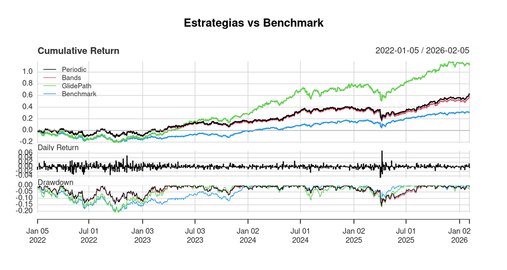

```r
R_comp <- na.omit(merge(r_periodic, r_bands, bench_use))
colnames(R_comp) <- c("Periodic","Bands","Benchmark")

if (!is.null(r_glide)) {
  R_comp <- na.omit(merge(r_periodic, r_bands, r_glide, bench_use))
  colnames(R_comp) <- c("Periodic","Bands","GlidePath","Benchmark")
}

charts.PerformanceSummary(R_comp, main="Estrategias vs Benchmark")
```

# 5 Consideraciones prácticas y límites

- **Costos reales:** aquí usamos el turnover como señal de cuánto se mueve el portafolio. En un caso real conviene sumar comisiones y spreads.
- **Cambios de mercado:** una estrategia puede funcionar mejor en algunos periodos y peor en otros. Por eso conviene mirar el gráfico y el drawdown.
- **Calidad de datos:** algunas métricas pueden faltar. El proceso está preparado para seguir funcionando aun con datos incompletos.
- **Benchmark:** ayuda a comparar la estrategia con una referencia simple.

# 6 Cómo reproducir

1. Ejecuta el documento de arriba hacia abajo.
2. Ajusta `cfg_sel`, `cfg_port` y `cfg_reb` según lo que quieras probar.
3. Salidas más importantes:
   - `sel$tickers_selected` (activos seleccionados),
   - `port$weights_target` (pesos objetivo),
   - `tbl` y `best_policy` (tabla y recomendación).